# Optimizing Projection Predictive Variable selection

Ludo Mels

Universiteit Utrecht

2026-09-29

## Introduction

*Projection predictive variable selection* (projpred) is a predictive model selection method.

Two steps (Piironen et al. 2020, 2156):

1. **Reference model**: “*Construct the best predictive model you can*”
2. **Minimal subset**: “*Find a simpler model that gives similar predictions as the reference model*”

**Projection** (McLatchie et al. 2025): “*we fit smaller models to the fit of the reference model*”

## Setup

This document follows the vignette about the `projpred` package. See: [projpred: Projection predictive feature selection](https://mc-stan.org/projpred/articles/projpred.html).

For the first part, only `rstanarm` is needed. Load using:

```r
library(rstanarm)
```

Ensure that you set the hyperprior scale for tau (i.e., here `tau0`)

## Fit a reference model

Fit a Bayesian reference model using parallel processing.

```r
# Set this manually if desired:
ncores <- parallel::detectCores(logical = FALSE)
options(mc.cores = ncores)

set.seed(50780)

# Fit reference model
refm_fit <- stan_glm(
  y ~ .,
  family = gaussian(),
  data = dat_gauss,
  prior = hs(global_scale = tau0),
  chains = 2, iter = 1000,
  refresh = 0
) |> suppressMessages()
```

## Projpred

Now, load the `projpred` package by:

```r
# Load projpred package
library(projpred)
```

## Search result

Now, you create a reference model object with `get_refmodel` and perform a search through the model space.

```r
refm_obj <- get_refmodel(refm_fit)
```

```r
# Refit the reference model K times:
cv_fits <- run_cvfun(
  refm_obj,
  K = 5
)

# Final cv_varsel() run:
cvvs <- cv_varsel(
  refm_obj,
  cv_method = "kfold",
  cvfits = cv_fits,
  method = "L1",
  nclusters_pred = 20,
  nterms_max = 9,          # determined in preliminary results
  parallel = FALSE,
  verbose = 0
)
```

## Plot summary

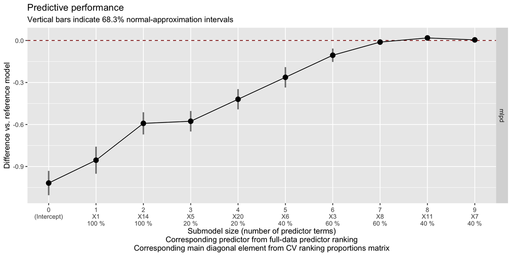

## Table summary

|  | size | ranking_fulldata | cv_proportions_diag | mlpd | mlpd.lower | mlpd.upper |
| --- | --- | --- | --- | --- | --- | --- |
| 1 | 0 | (Intercept) |  | -1.018076410128633 | -1.104944065644332 | -0.9312087546129343 |
| 2 | 1 | X1 | 1 | -0.8548993834408164 | -0.9515188879927909 | -0.7582798788888419 |
| 3 | 2 | X14 | 1 | -0.5918815848553681 | -0.6711762785177728 | -0.5125868911929634 |
| 4 | 3 | X5 | 0.2 | -0.5767716055048262 | -0.6499171631396718 | -0.5036260478699806 |
| 5 | 4 | X20 | 0.2 | -0.4196921286707436 | -0.4919811326519981 | -0.3474031246894891 |
| 6 | 5 | X6 | 0.4 | -0.2630192558744341 | -0.3357558613364238 | -0.1902826504124445 |
| 7 | 6 | X3 | 0.6 | -0.1054713213238642 | -0.1531554769444254 | -0.05778716570330301 |
| 8 | 7 | X8 | 0.6 | -0.01152464596001499 | -0.03124647857127359 | 0.008197186651243596 |
| 9 | 8 | X11 | 0.4 | 0.01827535604157791 | 0.001759151810255724 | 0.03479156027290009 |
| 10 | 9 | X7 | 0.4 | 0.004314166795492938 | -0.01045219800754361 | 0.01908053159852949 |

## The process can take some time

[figure not shown]

## The math

Piironen et al. (2020) (p. 2166) states that the discrepancy between the induced predictive distribution is defined as

$$\begin{align}
\mathrm{KL}\big(p(\tilde{y}\mid\mathcal{D}) \,\|\, q(\tilde{y})\big)
&= \mathrm{E}_{\tilde{y}}\big(\log p(\tilde{y}\mid\mathcal{D}) - \log q(\tilde{y})\big) \nonumber \\
&= -\mathrm{E}_{\tilde{y}}\big(\log q(\tilde{y})\big) + \text{const.} \nonumber \\
&= -\mathrm{E}_{\tilde{y}}\big(\log \mathrm{E}_{\boldsymbol{\theta}}\big(p(\tilde{y}\mid\boldsymbol{\theta})\big)\big) + \text{const.} \nonumber \\
&= -\mathrm{E}_{\boldsymbol{\theta}_*}\Big(\mathrm{E}_{\tilde{y}\mid\boldsymbol{\theta}_*}\big(\log \mathrm{E}_{\boldsymbol{\theta}}\big(p(\tilde{y}\mid\boldsymbol{\theta})\big)\big)\Big) + \text{const, }
\end{align}$$

although projection using *pointwise mapping* is used more often in practice.

## References

McLatchie, Yann, Sölvi Rögnvaldsson, Frank Weber, and Aki Vehtari. 2025. “Advances in Projection Predictive Inference.” *Statistical Science* 40 (1). https://doi.org/10.1214/24-STS949.

Piironen, Juho, Markus Paasiniemi, and Aki Vehtari. 2020. “Projective Inference in High-Dimensional Problems: Prediction and Feature Selection.” *Electronic Journal of Statistics* 14 (1). https://doi.org/10.1214/20-EJS1711.

## Disclaimer

**Note**

Note that this presentation was created as part of the course [Markup Languages and Reproducible Programming in Statistics](https://mlarpis.github.io/markup/). The key purpose of this presentation was to experiment with `.qmd` files as a markup format. Do not use any of the content.

Generative AI was used for copying the $\LaTeX$ equation from Piironen et al. (2020) (p. 2166) in Section 9, which corresponds to the AI index stated in the [course manual](https://mlarpis.github.io/markup/genai.html).